# 桃園縣住宅竊盜及自行車竊盜分析

陳安宇／B05305019

4/26/2017

## 導論

Using Taoyuan City’s Open Data information, I decided to do an analysis of two types of property crime from Mingguo 104 to the present day; bike theft and burglary. Prior to undertaking this analysis, I had assumed that the rates of bike theft and burglary would be about the same across districts, and that the rate of bike theft would be higher than the rate of burglary. My analysis proved me wrong. This analysis contains two histograms showing the frequency of crimes across districts, as well as a table with the raw data and the calculated percentage (number of crimes in district devided by total reported crimes).

## 圖表

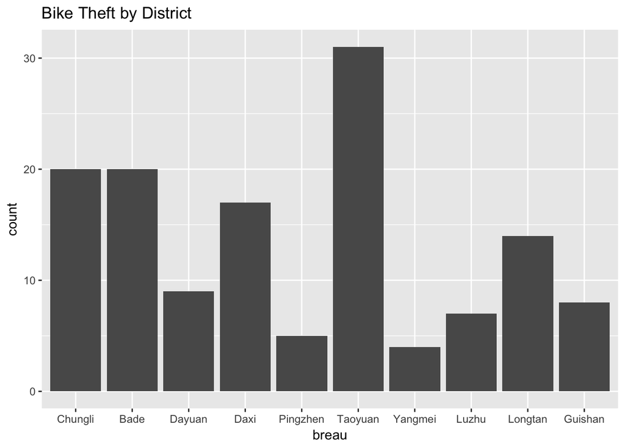

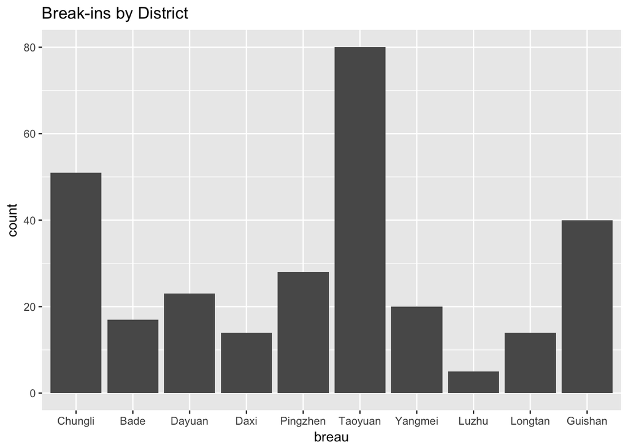

## 表格（含百分數）

Bike Theft and Break-ins by District

| Breau | Bike Theft | Bike Theft Percentages | Break-ins | Break-ins Percentages | Difference |
| --- | --- | --- | --- | --- | --- |
| Chungli | 20 | 14.8148148148148 | 51 | 17.4657534246575 | -2.65093860984272 |
| Bade | 20 | 14.8148148148148 | 17 | 5.82191780821918 | 8.99289700659564 |
| Dayuan | 9 | 6.66666666666667 | 23 | 7.87671232876712 | -1.21004566210046 |
| Daxi | 17 | 12.5925925925926 | 14 | 4.79452054794521 | 7.79807204464739 |
| Pingzhen | 5 | 3.7037037037037 | 28 | 9.58904109589041 | -5.88533739218671 |
| Taoyuan | 31 | 22.962962962963 | 80 | 27.3972602739726 | -4.43429731100964 |
| Yangmei | 4 | 2.96296296296296 | 20 | 6.84931506849315 | -3.88635210553019 |
| Luzhu | 7 | 5.18518518518519 | 5 | 1.71232876712329 | 3.4728564180619 |
| Longtan | 14 | 10.3703703703704 | 14 | 4.79452054794521 | 5.57584982242517 |
| Guishan | 8 | 5.92592592592593 | 40 | 13.6986301369863 | -7.77270421106037 |
| Total | 135 | 100 | 292 | 100 | - |

## 結論

As displayed in the graphs, not only is the rate of reported burglary much higher than the rate of reported bike theft, but there are a number of districts with a large difference in percentages. Most notibly, Bade district has 14.81% of Taoyuan’s bike thefts, but only 5.82% of Taoyuan’s burglaries. Guishan district has only 5.92% of Taoyuan’s reported bike thefts, but 13.69% of Taoyuan’s reported burglaries.

I believe that the difference in reported totals can be easily explained- the average person is probably unlikely to report their stolen bicycle to the police, so the actual number of stolen bikes may be much higher than reported. It is much harder, however, to easily explain why some districts have such a large difference in types of crime. Better and more complete data would allow for better conclusions to be drawn.